# Project Proposal

Seokjun Choi and Sho Kawano

2021-11-02

## Background

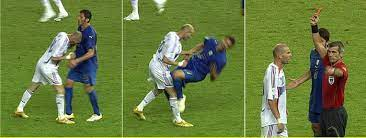

Sports psychologists have been trying to understand the effect of anger on sports performance for a long time.

Key question: do athletes handle anger differently than non-athletes?

## How do psychologists measure anger management?

One way: questionnaire called STATXI-2 which produces the anger expression (AE) index.

AE: overall estimate of the person’s tendencies to express anger either outwardly toward other people, or inwardly toward herself

## Components of Anger Expression Index

$AE = AO + AI - CO - CI +48$

- Anger-Out (AO): how much a person expresses their anger in an outwardly negative and poorly controlled manner.
- Anger-In (AI): the extent to which people hold things in or suppress anger when they are angry or furious.
- Control-Out (CO): measures how much effort does the person expend to control anger.
- Control-In (CI): measures how often a person attempts to relax, calm down.

# Data Description

```
##   Sex Athlete Anger.Out Anger.In Control.Out Control.In Anger_Expression
## 1   0       1        18       13          23         20               36
## 2   0       1        14       17          25         24               30
## 3   0       1        13       14          28         28               19
## 4   0       1        17       24          23         23               43
## 5   1       1        16       17          26         28               27
## 6   1       1        16       22          25         23               38
```

Contingency table:

```
##    Athlete
## Sex  0  1
##   0 34 14
##   1 19 11
```

# Main Research Questions

- Do athletes and non-athletes deal with anger in the same way?
- Are there any gender differences?
- If there are differences by gender and athlete status, how do they differ?
- Are there relationships among AO, AI, CO, CI?

# EDA

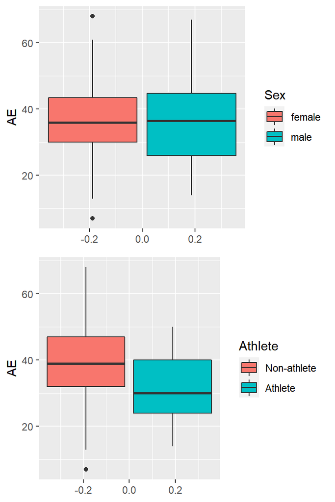

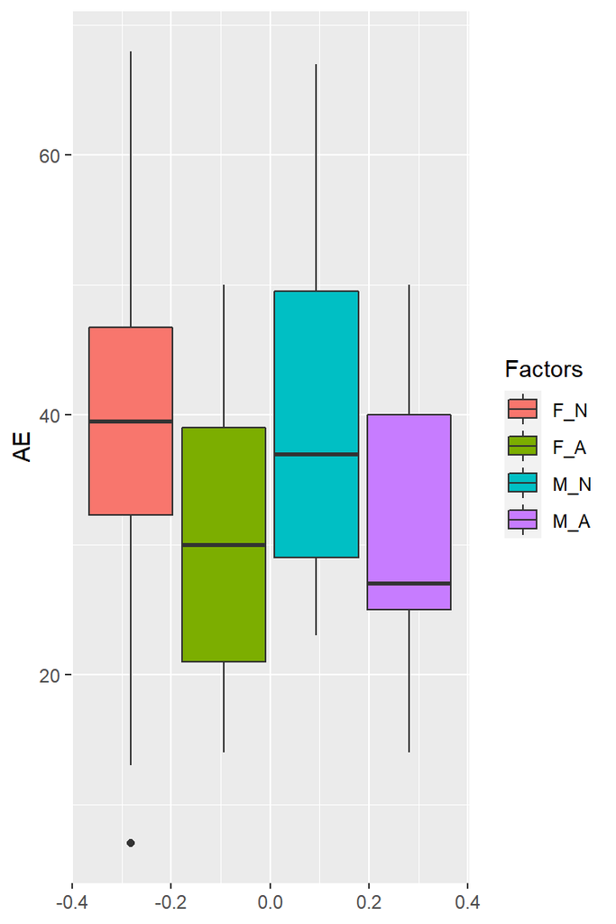

# EDA

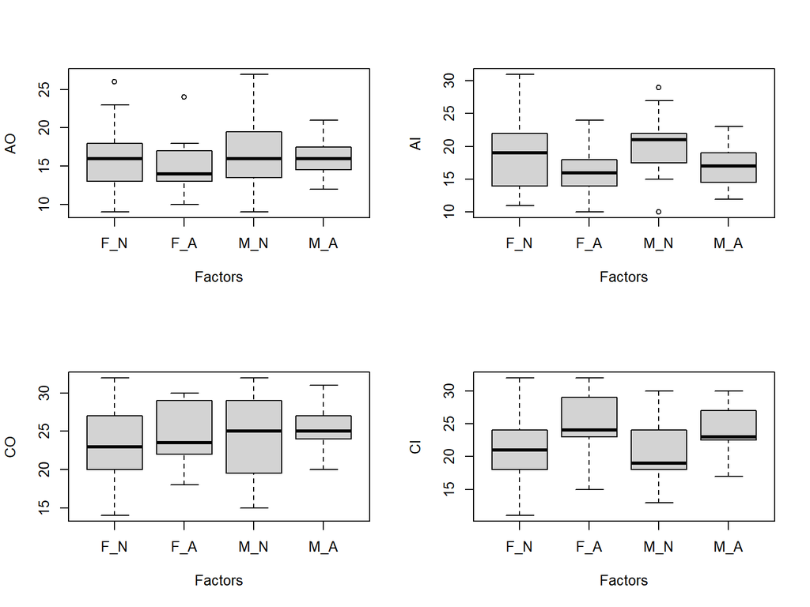

# Two-Way ANOVA

$$AE = \mu + \alpha_i + \beta_j + \gamma_{i,j} +\epsilon$$
where $\epsilon \sim Normal(0, \sigma^2)$ for fixed $\sigma^2$

- $\alpha_i$: effect of ‘gender’ (i = 0(female), 1(male))
- $\beta_i$: effect of ‘being an athlete’ (i = 0(non-athlete), 1(athlete))
- $\gamma_{i,j}$: interaction between gender and being an athlete

Then two main questions reduce to

- $\alpha_0 = \alpha_1$? or $\alpha_0 \neq \alpha_1$?
- $\beta_0 = \beta_1$? or $\beta_0 \neq \beta_1$?

If so, how do they differ?

# Explore Relationships

Can we explain ‘AO’ by other variables?

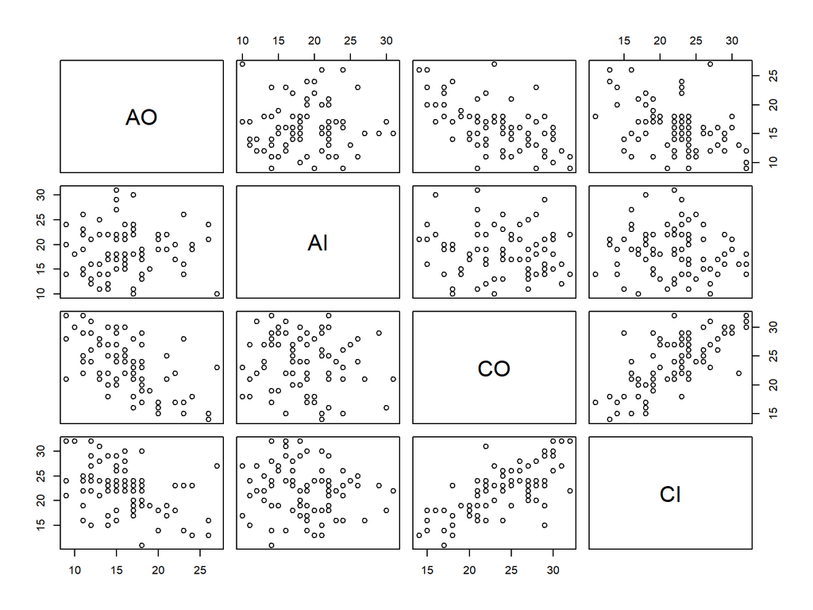

# Discussion

Any questions? Comments? Suggestions?

# Additional plots 1

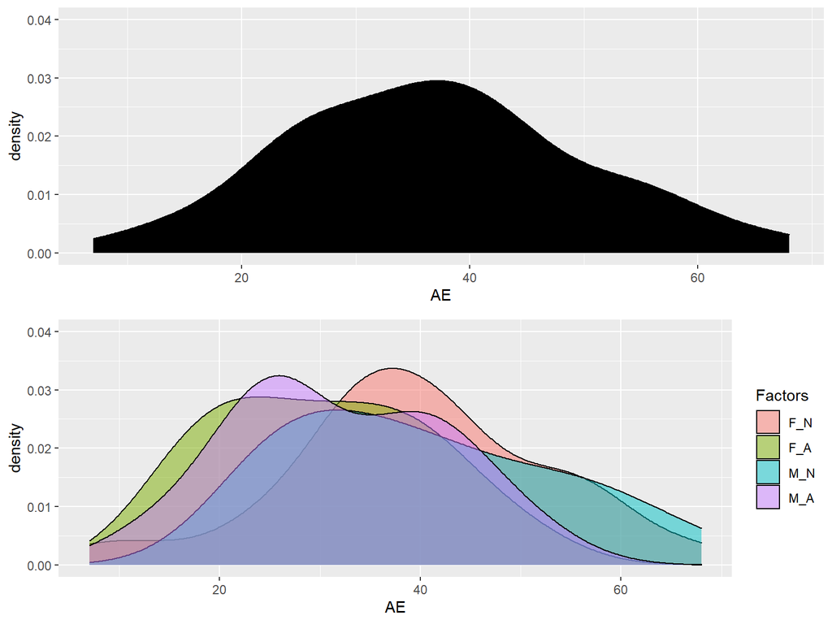

# Additional plots 2

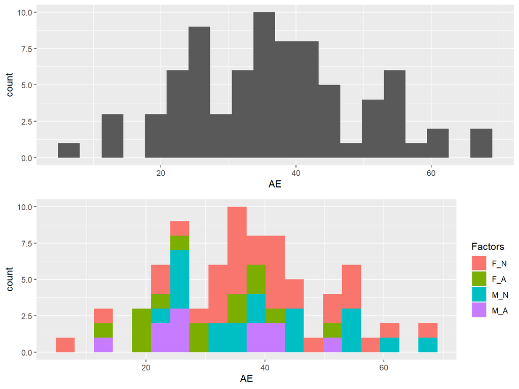

# Additional plots 3

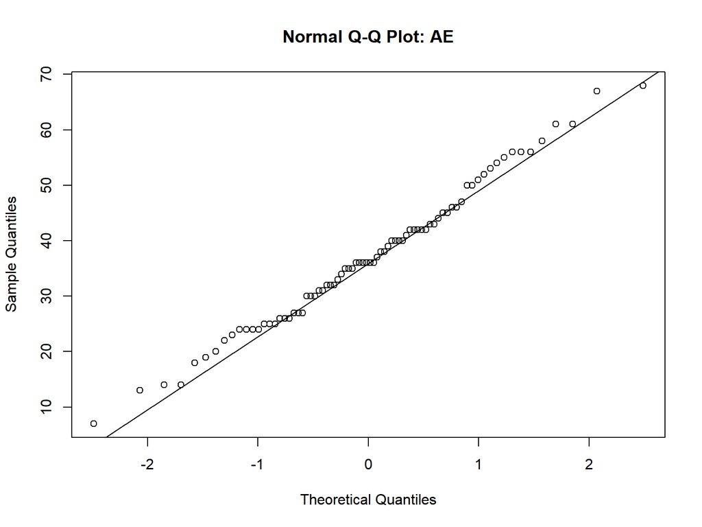